# Class 17: Mini Project

Jessica Diaz-Vigil

2023-05-31

# Getting Started

```r
vax <- read.csv("covid19vaccinesbyzipcode_test.csv")
head(vax)
```

```
##   as_of_date zip_code_tabulation_area local_health_jurisdiction      county
## 1 2021-01-05                    94579                   Alameda     Alameda
## 2 2021-01-05                    93726                    Fresno      Fresno
## 3 2021-01-05                    94305               Santa Clara Santa Clara
## 4 2021-01-05                    93704                    Fresno      Fresno
## 5 2021-01-05                    94403                 San Mateo   San Mateo
## 6 2021-01-05                    93668                    Fresno      Fresno
##   vaccine_equity_metric_quartile                 vem_source
## 1                              3 Healthy Places Index Score
## 2                              1 Healthy Places Index Score
## 3                              4 Healthy Places Index Score
## 4                              1 Healthy Places Index Score
## 5                              4 Healthy Places Index Score
## 6                              1    CDPH-Derived ZCTA Score
##   age12_plus_population age5_plus_population tot_population
```

[output cut: 55 more lines]

**Q1.** What column details the total number of people fully vaccinated?

```r
colnames(vax)
```

```
##  [1] "as_of_date"
##  [2] "zip_code_tabulation_area"
##  [3] "local_health_jurisdiction"
##  [4] "county"
##  [5] "vaccine_equity_metric_quartile"
##  [6] "vem_source"
##  [7] "age12_plus_population"
##  [8] "age5_plus_population"
##  [9] "tot_population"
## [10] "persons_fully_vaccinated"
## [11] "persons_partially_vaccinated"
## [12] "percent_of_population_fully_vaccinated"
## [13] "percent_of_population_partially_vaccinated"
## [14] "percent_of_population_with_1_plus_dose"
## [15] "booster_recip_count"
## [16] "bivalent_dose_recip_count"
## [17] "eligible_recipient_count"
## [18] "eligible_bivalent_recipient_count"
## [19] "redacted"
```

The column that represents the total number of people fully vaccinated it “persons_fully_vaccinated”

**Q2.** What column details the Zip code tabulation area?

```r
colnames(vax)
```

```
##  [1] "as_of_date"
##  [2] "zip_code_tabulation_area"
##  [3] "local_health_jurisdiction"
##  [4] "county"
##  [5] "vaccine_equity_metric_quartile"
##  [6] "vem_source"
##  [7] "age12_plus_population"
##  [8] "age5_plus_population"
##  [9] "tot_population"
## [10] "persons_fully_vaccinated"
## [11] "persons_partially_vaccinated"
## [12] "percent_of_population_fully_vaccinated"
## [13] "percent_of_population_partially_vaccinated"
## [14] "percent_of_population_with_1_plus_dose"
## [15] "booster_recip_count"
## [16] "bivalent_dose_recip_count"
## [17] "eligible_recipient_count"
## [18] "eligible_bivalent_recipient_count"
## [19] "redacted"
```

**Q3.** What is the earliest date in this dataset?

```r
table(vax$as_of_date)
```

```
##
## 2021-01-05 2021-01-12 2021-01-19 2021-01-26 2021-02-02 2021-02-09 2021-02-16
##       1764       1764       1764       1764       1764       1764       1764
## 2021-02-23 2021-03-02 2021-03-09 2021-03-16 2021-03-23 2021-03-30 2021-04-06
##       1764       1764       1764       1764       1764       1764       1764
## 2021-04-13 2021-04-20 2021-04-27 2021-05-04 2021-05-11 2021-05-18 2021-05-25
##       1764       1764       1764       1764       1764       1764       1764
## 2021-06-01 2021-06-08 2021-06-15 2021-06-22 2021-06-29 2021-07-06 2021-07-13
##       1764       1764       1764       1764       1764       1764       1764
## 2021-07-20 2021-07-27 2021-08-03 2021-08-10 2021-08-17 2021-08-24 2021-08-31
##       1764       1764       1764       1764       1764       1764       1764
## 2021-09-07 2021-09-14 2021-09-21 2021-09-28 2021-10-05 2021-10-12 2021-10-19
##       1764       1764       1764       1764       1764       1764       1764
## 2021-10-26 2021-11-02 2021-11-09 2021-11-16 2021-11-23 2021-11-30 2021-12-07
##       1764       1764       1764       1764       1764       1764       1764
## 2021-12-14 2021-12-21 2021-12-28 2022-01-04 2022-01-11 2022-01-18 2022-01-25
##       1764       1764       1764       1764       1764       1764       1764
## 2022-02-01 2022-02-08 2022-02-15 2022-02-22 2022-03-01 2022-03-08 2022-03-15
##       1764       1764       1764       1764       1764       1764       1764
## 2022-03-22 2022-03-29 2022-04-05 2022-04-12 2022-04-19 2022-04-26 2022-05-03
##       1764       1764       1764       1764       1764       1764       1764
## 2022-05-10 2022-05-17 2022-05-24 2022-05-31 2022-06-07 2022-06-14 2022-06-21
##       1764       1764       1764       1764       1764       1764       1764
## 2022-06-28 2022-07-05 2022-07-12 2022-07-19 2022-07-26 2022-08-02 2022-08-09
##       1764       1764       1764       1764       1764       1764       1764
## 2022-08-16 2022-08-23 2022-08-30 2022-09-06 2022-09-13 2022-09-20 2022-09-27
##       1764       1764       1764       1764       1764       1764       1764
## 2022-10-04 2022-10-11 2022-10-18 2022-10-25 2022-11-01 2022-11-08 2022-11-15
##       1764       1764       1764       1764       1764       1764       1764
## 2022-11-22 2022-11-29 2022-12-06 2022-12-13 2022-12-20 2022-12-27 2023-01-03
##       1764       1764       1764       1764       1764       1764       1764
## 2023-01-10 2023-01-17 2023-01-24 2023-01-31 2023-02-07 2023-02-14 2023-02-21
##       1764       1764       1764       1764       1764       1764       1764
## 2023-02-28 2023-03-07 2023-03-14 2023-03-21 2023-03-28 2023-04-04 2023-04-11
##       1764       1764       1764       1764       1764       1764       1764
## 2023-04-18 2023-04-25 2023-05-02 2023-05-09 2023-05-16 2023-05-23
##       1764       1764       1764       1764       1764       1764
```

**Q4.** What is the latest date in this dataset?

```r
table(vax$as_of_date)
```

```
##
## 2021-01-05 2021-01-12 2021-01-19 2021-01-26 2021-02-02 2021-02-09 2021-02-16
##       1764       1764       1764       1764       1764       1764       1764
## 2021-02-23 2021-03-02 2021-03-09 2021-03-16 2021-03-23 2021-03-30 2021-04-06
##       1764       1764       1764       1764       1764       1764       1764
## 2021-04-13 2021-04-20 2021-04-27 2021-05-04 2021-05-11 2021-05-18 2021-05-25
##       1764       1764       1764       1764       1764       1764       1764
## 2021-06-01 2021-06-08 2021-06-15 2021-06-22 2021-06-29 2021-07-06 2021-07-13
##       1764       1764       1764       1764       1764       1764       1764
## 2021-07-20 2021-07-27 2021-08-03 2021-08-10 2021-08-17 2021-08-24 2021-08-31
##       1764       1764       1764       1764       1764       1764       1764
## 2021-09-07 2021-09-14 2021-09-21 2021-09-28 2021-10-05 2021-10-12 2021-10-19
##       1764       1764       1764       1764       1764       1764       1764
## 2021-10-26 2021-11-02 2021-11-09 2021-11-16 2021-11-23 2021-11-30 2021-12-07
##       1764       1764       1764       1764       1764       1764       1764
## 2021-12-14 2021-12-21 2021-12-28 2022-01-04 2022-01-11 2022-01-18 2022-01-25
##       1764       1764       1764       1764       1764       1764       1764
## 2022-02-01 2022-02-08 2022-02-15 2022-02-22 2022-03-01 2022-03-08 2022-03-15
##       1764       1764       1764       1764       1764       1764       1764
## 2022-03-22 2022-03-29 2022-04-05 2022-04-12 2022-04-19 2022-04-26 2022-05-03
##       1764       1764       1764       1764       1764       1764       1764
## 2022-05-10 2022-05-17 2022-05-24 2022-05-31 2022-06-07 2022-06-14 2022-06-21
##       1764       1764       1764       1764       1764       1764       1764
## 2022-06-28 2022-07-05 2022-07-12 2022-07-19 2022-07-26 2022-08-02 2022-08-09
##       1764       1764       1764       1764       1764       1764       1764
## 2022-08-16 2022-08-23 2022-08-30 2022-09-06 2022-09-13 2022-09-20 2022-09-27
##       1764       1764       1764       1764       1764       1764       1764
## 2022-10-04 2022-10-11 2022-10-18 2022-10-25 2022-11-01 2022-11-08 2022-11-15
##       1764       1764       1764       1764       1764       1764       1764
## 2022-11-22 2022-11-29 2022-12-06 2022-12-13 2022-12-20 2022-12-27 2023-01-03
##       1764       1764       1764       1764       1764       1764       1764
## 2023-01-10 2023-01-17 2023-01-24 2023-01-31 2023-02-07 2023-02-14 2023-02-21
##       1764       1764       1764       1764       1764       1764       1764
## 2023-02-28 2023-03-07 2023-03-14 2023-03-21 2023-03-28 2023-04-04 2023-04-11
##       1764       1764       1764       1764       1764       1764       1764
## 2023-04-18 2023-04-25 2023-05-02 2023-05-09 2023-05-16 2023-05-23
##       1764       1764       1764       1764       1764       1764
```

```r
skimr::skim_without_charts(vax)
```

Data summary

| Name | vax |
| --- | --- |
| Number of rows | 220500 |
| Number of columns | 19 |
| _______________________ |  |
| Column type frequency: |  |
| character | 5 |
| numeric | 14 |
| ________________________ |  |
| Group variables | None |

**Variable type: character**

| skim_variable | n_missing | complete_rate | min | max | empty | n_unique | whitespace |
| --- | --- | --- | --- | --- | --- | --- | --- |
| as_of_date | 0 | 1 | 10 | 10 | 0 | 125 | 0 |
| local_health_jurisdiction | 0 | 1 | 0 | 15 | 625 | 62 | 0 |
| county | 0 | 1 | 0 | 15 | 625 | 59 | 0 |
| vem_source | 0 | 1 | 15 | 26 | 0 | 3 | 0 |
| redacted | 0 | 1 | 2 | 69 | 0 | 2 | 0 |

**Variable type: numeric**

| skim_variable | n_missing | complete_rate | mean | sd | p0 | p25 | p50 | p75 | p100 |
| --- | --- | --- | --- | --- | --- | --- | --- | --- | --- |
| zip_code_tabulation_area | 0 | 1.00 | 93665.11 | 1817.38 | 90001 | 92257.75 | 93658.50 | 95380.50 | 97635.0 |
| vaccine_equity_metric_quartile | 10875 | 0.95 | 2.44 | 1.11 | 1 | 1.00 | 2.00 | 3.00 | 4.0 |
| age12_plus_population | 0 | 1.00 | 18895.04 | 18993.87 | 0 | 1346.95 | 13685.10 | 31756.12 | 88556.7 |
| age5_plus_population | 0 | 1.00 | 20875.24 | 21105.97 | 0 | 1460.50 | 15364.00 | 34877.00 | 101902.0 |
| tot_population | 10750 | 0.95 | 23372.77 | 22628.50 | 12 | 2126.00 | 18714.00 | 38168.00 | 111165.0 |
| persons_fully_vaccinated | 17711 | 0.92 | 14272.72 | 15264.17 | 11 | 954.00 | 8990.00 | 23782.00 | 87724.0 |
| persons_partially_vaccinated | 17711 | 0.92 | 1711.05 | 2071.56 | 11 | 164.00 | 1203.00 | 2550.00 | 42259.0 |
| percent_of_population_fully_vaccinated | 22579 | 0.90 | 0.58 | 0.25 | 0 | 0.44 | 0.62 | 0.75 | 1.0 |
| percent_of_population_partially_vaccinated | 22579 | 0.90 | 0.08 | 0.09 | 0 | 0.05 | 0.06 | 0.08 | 1.0 |
| percent_of_population_with_1_plus_dose | 23732 | 0.89 | 0.64 | 0.24 | 0 | 0.50 | 0.68 | 0.82 | 1.0 |
| booster_recip_count | 74388 | 0.66 | 6373.43 | 7751.70 | 11 | 328.00 | 3097.00 | 10274.00 | 60022.0 |
| bivalent_dose_recip_count | 159956 | 0.27 | 3407.91 | 4010.38 | 11 | 222.00 | 1832.00 | 5482.00 | 29484.0 |
| eligible_recipient_count | 0 | 1.00 | 13120.40 | 15126.17 | 0 | 534.00 | 6663.00 | 22517.25 | 87437.0 |
| eligible_bivalent_recipient_count | 0 | 1.00 | 13016.51 | 15199.08 | 0 | 266.00 | 6562.00 | 22513.00 | 87437.0 |

**Q5.** How many numeric columns are in this dataset?

By looking at the data summary using skim, there are 14 numeric columns in the dataset

**Q6.** Note that there are "missing values" in the dataset. How many `NA` values there in the `persons_fully_vaccinated`column?

```r
total_na_full_vac <- sum(is.na(vax$persons_fully_vaccinated))
total_na_full_vac
```

```
## [1] 17711
```

There are 17711 NA values in the “persons_fully_vaccinated” column

**Q7.** What percent of `persons_fully_vaccinated` values are missing (to 2 significant figures)?

```r
total_full_vac <- nrow(vax)
total_full_vac
```

```
## [1] 220500
```

```r
total_na_full_vac / total_full_vac * 100
```

```
## [1] 8.0322
```

The percent of missing values is 8.03%

# Working With Dates

```r
library(lubridate)
today()
```

```
## [1] "2023-05-31"
```

```r
vax$as_of_date <- ymd(vax$as_of_date)
```

```r
days_since_first <- today() - vax$as_of_date[1]
days_since_first
```

```
## Time difference of 876 days
```

```r
days_in_data <- vax$as_of_date[nrow(vax)] - vax$as_of_date[1]
days_in_data
```

```
## Time difference of 868 days
```

**Q9.** How many days have passed since the last update of the dataset?

```r
days_since_first - days_in_data
```

```
## Time difference of 8 days
```

8 days have passed since the last update

**Q10.** How many unique dates are in the dataset (i.e. how many different dates are detailed)?

```r
unique_dates <- unique(vax$as_of_date)
unique_dates
```

```
##   [1] "2021-01-05" "2021-01-12" "2021-01-19" "2021-01-26" "2021-02-02"
##   [6] "2021-02-09" "2021-02-16" "2021-02-23" "2021-03-02" "2021-03-09"
##  [11] "2021-03-16" "2021-03-23" "2021-03-30" "2021-04-06" "2021-04-13"
##  [16] "2021-04-20" "2021-04-27" "2021-05-04" "2021-05-11" "2021-05-18"
##  [21] "2021-05-25" "2021-06-01" "2021-06-08" "2021-06-15" "2021-06-22"
##  [26] "2021-06-29" "2021-07-06" "2021-07-13" "2021-07-20" "2021-07-27"
##  [31] "2021-08-03" "2021-08-10" "2021-08-17" "2021-08-24" "2021-08-31"
##  [36] "2021-09-07" "2021-09-14" "2021-09-21" "2021-09-28" "2021-10-05"
##  [41] "2021-10-12" "2021-10-19" "2021-10-26" "2021-11-02" "2021-11-09"
##  [46] "2021-11-16" "2021-11-23" "2021-11-30" "2021-12-07" "2021-12-14"
##  [51] "2021-12-21" "2021-12-28" "2022-01-04" "2022-01-11" "2022-01-18"
##  [56] "2022-01-25" "2022-02-01" "2022-02-08" "2022-02-15" "2022-02-22"
##  [61] "2022-03-01" "2022-03-08" "2022-03-15" "2022-03-22" "2022-03-29"
##  [66] "2022-04-05" "2022-04-12" "2022-04-19" "2022-04-26" "2022-05-03"
##  [71] "2022-05-10" "2022-05-17" "2022-05-24" "2022-05-31" "2022-06-07"
##  [76] "2022-06-14" "2022-06-21" "2022-06-28" "2022-07-05" "2022-07-12"
##  [81] "2022-07-19" "2022-07-26" "2022-08-02" "2022-08-09" "2022-08-16"
##  [86] "2022-08-23" "2022-08-30" "2022-09-06" "2022-09-13" "2022-09-20"
##  [91] "2022-09-27" "2022-10-04" "2022-10-11" "2022-10-18" "2022-10-25"
##  [96] "2022-11-01" "2022-11-08" "2022-11-15" "2022-11-22" "2022-11-29"
## [101] "2022-12-06" "2022-12-13" "2022-12-20" "2022-12-27" "2023-01-03"
## [106] "2023-01-10" "2023-01-17" "2023-01-24" "2023-01-31" "2023-02-07"
## [111] "2023-02-14" "2023-02-21" "2023-02-28" "2023-03-07" "2023-03-14"
## [116] "2023-03-21" "2023-03-28" "2023-04-04" "2023-04-11" "2023-04-18"
## [121] "2023-04-25" "2023-05-02" "2023-05-09" "2023-05-16" "2023-05-23"
```

```r
length(unique_dates)
```

```
## [1] 125
```

There are 125 unique dates in the dataset

# Working With Zip Codes

```r
#install.packages('zipcodeR')
library(zipcodeR)
```

```r
geocode_zip('92037')
```

```
## # A tibble: 1 × 3
##   zipcode   lat   lng
##   <chr>   <dbl> <dbl>
## 1 92037    32.8 -117.
```

```r
zip_distance('92037','92109')
```

```
##   zipcode_a zipcode_b distance
## 1     92037     92109     2.33
```

```r
reverse_zipcode(c('92037', "92109") )
```

```
## # A tibble: 2 × 24
##   zipcode zipcode_type major_city post_office_city common_city_list county state
##   <chr>   <chr>        <chr>      <chr>                      <blob> <chr>  <chr>
## 1 92037   Standard     La Jolla   La Jolla, CA           <raw 20 B> San D… CA
## 2 92109   Standard     San Diego  San Diego, CA          <raw 21 B> San D… CA
## # ℹ 17 more variables: lat <dbl>, lng <dbl>, timezone <chr>,
## #   radius_in_miles <dbl>, area_code_list <blob>, population <int>,
## #   population_density <dbl>, land_area_in_sqmi <dbl>,
## #   water_area_in_sqmi <dbl>, housing_units <int>,
## #   occupied_housing_units <int>, median_home_value <int>,
## #   median_household_income <int>, bounds_west <dbl>, bounds_east <dbl>,
## #   bounds_north <dbl>, bounds_south <dbl>
```

# Focus On The San Diego Area

```r
sd <- vax[ vax$county == "San Diego" , ]
head(sd)
```

```
##     as_of_date zip_code_tabulation_area local_health_jurisdiction    county
## 134 2021-01-05                    91977                 San Diego San Diego
## 171 2021-01-05                    92110                 San Diego San Diego
## 173 2021-01-05                    92101                 San Diego San Diego
## 175 2021-01-05                    92071                 San Diego San Diego
## 176 2021-01-05                    92070                 San Diego San Diego
## 178 2021-01-05                    92028                 San Diego San Diego
##     vaccine_equity_metric_quartile                 vem_source
## 134                              2 Healthy Places Index Score
## 171                              3 Healthy Places Index Score
## 173                              2 Healthy Places Index Score
## 175                              3 Healthy Places Index Score
## 176                              2    CDPH-Derived ZCTA Score
## 178                              2 Healthy Places Index Score
##     age12_plus_population age5_plus_population tot_population
```

[output cut: 55 more lines]

```r
library(dplyr)
sd <- filter(vax, county == "San Diego")
nrow(sd)
```

```
## [1] 13375
```

```r
sd.10 <- filter(vax, county == "San Diego" &
                age5_plus_population > 10000)
```

**Q11.** How many distinct zip codes are listed for San Diego County?

```r
unique_zip_sd <- unique(sd$zip_code_tabulation_area)
length(unique_zip_sd)
```

```
## [1] 107
```

There are 107 unique zip codes in San Diego

Q12. What San Diego County Zip code area has the largest population in this dataset?

```r
which.max(sd$tot_population)
```

```
## [1] 87
```

```r
sd$zip_code_tabulation_area[87]
```

```
## [1] 92154
```

The zip code 92154 has the largest population

**Q13.** What is the overall average (with 2 decimal numbers) "Percent of Population Fully Vaccinated" value for all San Diego "County" as of "2023-05-23"?

```r
sd.1 <- filter(sd.10, county == "San Diego" &
                as_of_date == "2023-05-23")
head(sd.1)
```

```
##   as_of_date zip_code_tabulation_area local_health_jurisdiction    county
## 1 2023-05-23                    91932                 San Diego San Diego
## 2 2023-05-23                    92124                 San Diego San Diego
## 3 2023-05-23                    92014                 San Diego San Diego
## 4 2023-05-23                    92009                 San Diego San Diego
## 5 2023-05-23                    92057                 San Diego San Diego
## 6 2023-05-23                    92102                 San Diego San Diego
##   vaccine_equity_metric_quartile                 vem_source
## 1                              2 Healthy Places Index Score
## 2                              3 Healthy Places Index Score
## 3                              4 Healthy Places Index Score
## 4                              4 Healthy Places Index Score
## 5                              2 Healthy Places Index Score
## 6                              1 Healthy Places Index Score
##   age12_plus_population age5_plus_population tot_population
```

[output cut: 48 more lines]

```r
mean(na.omit(sd.1$percent_of_population_fully_vaccinated))
```

```
## [1] 0.7383022
```

**Q14.** Using either ggplot or base R graphics make a summary figure that shows the distribution of Percent of Population Fully Vaccinated values as of "2023-05-23"?

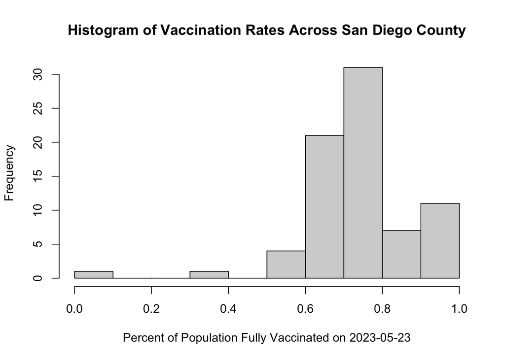

```r
hist(sd.1$percent_of_population_fully_vaccinated, main = "Histogram of Vaccination Rates Across San Diego County" , xlab = "Percent of Population Fully Vaccinated on 2023-05-23")
```

# Focus On UCSD/La Jolla

```r
ucsd <- filter(sd, zip_code_tabulation_area=="92037")
ucsd[1,]$age5_plus_population
```

```
## [1] 36144
```

```r
dim(ucsd)
```

```
## [1] 125  19
```

**Q15**. Using **ggplot** make a graph of the vaccination rate time course for the 92037 ZIP code area:

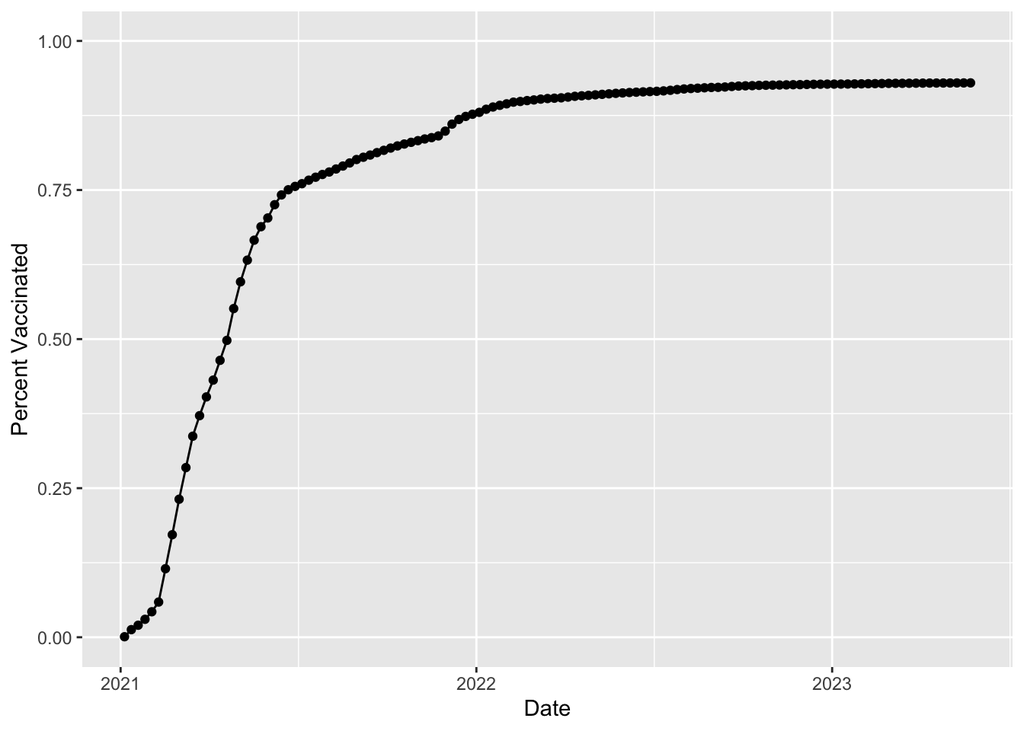

```r
library(ggplot2)
p <- ggplot(ucsd) +
  aes(x = as_of_date,
      y = percent_of_population_fully_vaccinated) +
  geom_point() +
  geom_line(group=1) +
  ylim(c(0,1)) +
  labs(x="Date", y="Percent Vaccinated")
p
```

# Comparing To Similar Sized Areas

```r
vax.36 <- filter(vax, age5_plus_population > 36144 &
                as_of_date == "2023-05-23")
head(vax.36)
```

```
##   as_of_date zip_code_tabulation_area local_health_jurisdiction       county
## 1 2023-05-23                    93720                    Fresno       Fresno
## 2 2023-05-23                    95670                Sacramento   Sacramento
## 3 2023-05-23                    91405               Los Angeles  Los Angeles
## 4 2023-05-23                    94582              Contra Costa Contra Costa
## 5 2023-05-23                    95687                    Solano       Solano
## 6 2023-05-23                    92627                    Orange       Orange
##   vaccine_equity_metric_quartile                 vem_source
## 1                              3 Healthy Places Index Score
## 2                              2 Healthy Places Index Score
## 3                              1 Healthy Places Index Score
## 4                              4 Healthy Places Index Score
## 5                              3 Healthy Places Index Score
## 6                              2 Healthy Places Index Score
##   age12_plus_population age5_plus_population tot_population
```

[output cut: 48 more lines]

**Q16**. Calculate the mean *"Percent of Population Fully Vaccinated"* for ZIP code areas with a population as large as 92037 (La Jolla) *as_of_date* "2023-05-23". Add this as a straight horizontal line to your plot from above with the `geom_hline()`function?

```r
mean.vax.36 <- mean(vax.36$percent_of_population_fully_vaccinated)
mean.vax.36
```

```
## [1] 0.7225892
```

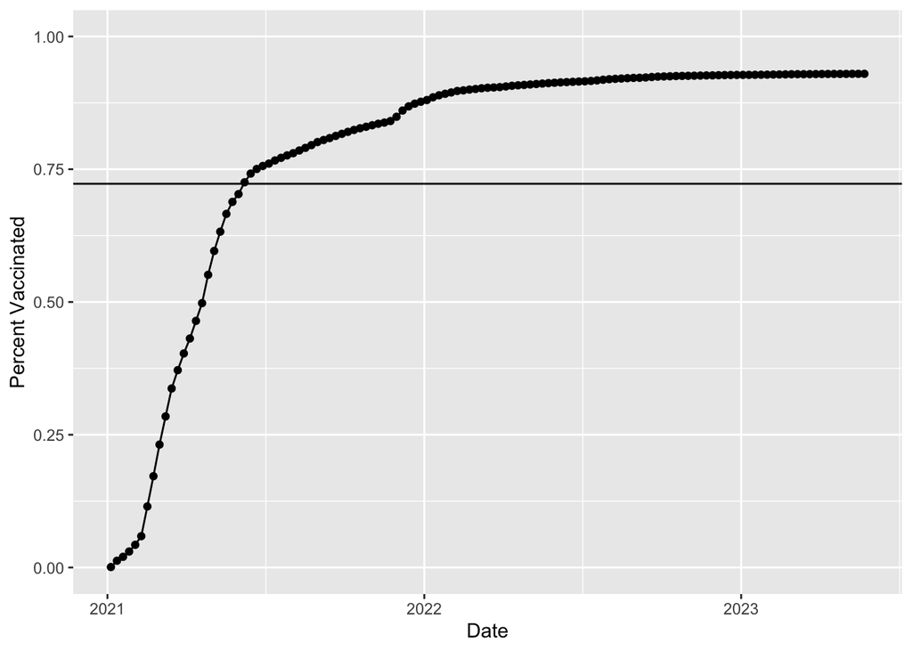

```r
p + geom_hline(yintercept = mean.vax.36)
```

**Q17.** What is the 6 number summary (Min, 1st Qu., Median, Mean, 3rd Qu., and Max) of the *"Percent of Population Fully Vaccinated"*values for ZIP code areas with a population as large as 92037 (La Jolla) *as_of_date* "2023-05-23"?

```r
summary(vax.36$percent_of_population_fully_vaccinated)
```

```
##    Min. 1st Qu.  Median    Mean 3rd Qu.    Max.
##  0.3816  0.6469  0.7207  0.7226  0.7924  1.0000
```

The 6 number summary is above

**Q18.** Using ggplot generate a histogram of this data

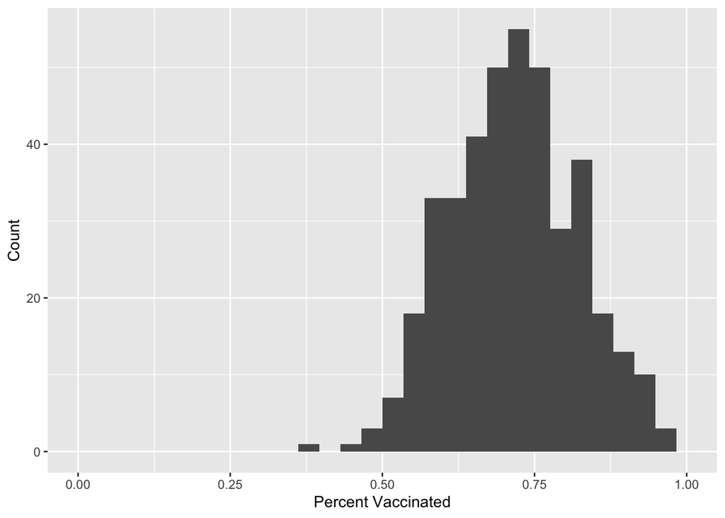

```r
ggplot(vax.36) +
  aes(x = percent_of_population_fully_vaccinated) +
  geom_histogram() +
  xlab("Percent Vaccinated") +
  ylab("Count") +
  xlim(c(0,1))
```

**Q19**. Is the 92109 and 92040 ZIP code areas above or below the average value you calculated for all these above?

```r
vax %>% filter(as_of_date == "2023-05-23") %>%
  filter(zip_code_tabulation_area=="92040") %>%
  select(percent_of_population_fully_vaccinated)
```

```
##   percent_of_population_fully_vaccinated
## 1                               0.552434
```

This value is below the other average we found ( 0.55 compared to 0.72)

**Q20.** Finally make a time course plot of vaccination progress for all areas in the full dataset with a`age5_plus_population > 36144`

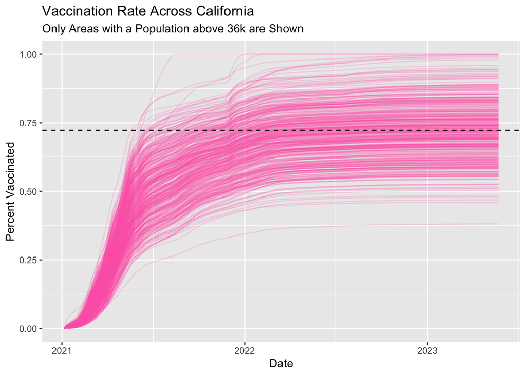

```r
vax.36.all <- filter(vax, age5_plus_population > 36144)

ggplot(vax.36.all) +
  aes(as_of_date,
      percent_of_population_fully_vaccinated,
      group=zip_code_tabulation_area) +
  geom_line(alpha=0.2, color="hotpink") +
  ylim(c(0,1)) +
  labs(x="Date", y="Percent Vaccinated",
       title="Vaccination Rate Across California",
       subtitle="Only Areas with a Population above 36k are Shown") +
  geom_hline(yintercept = mean.vax.36, linetype="dashed")
```